# A Nonparametric Alternative to MANOVA

# Hotelling-Lawley Trace Test

$$T_0 = \text{tr}(\mathbf{W}^{-1}\mathbf{B})$$

This statistic has an approximation to the $\chi^2$ distribution as below:

$$nT_0^2\sim\chi^2_{p(g-1)}.$$

This statistic has also another approximation to F distribution.

# Roy’s Largest Root Test

$$\theta_{\max} = \frac{\lambda_{\max}}{1+\lambda_{\max}}$$
where $\lambda_{\max}$ is the largest eigenvalue. This statistic has an approximation to the F distribution.

# MANOVA in R

The function `manova()` in **`stats`** package can be used to perform MANOVA in R (Team 2023; Bulut 2019a).

```r
str(iris)
```

```
## 'data.frame':    150 obs. of  5 variables:
##  $ Sepal.Length: num  5.1 4.9 4.7 4.6 5 5.4 4.6 5 4.4 4.9 ...
##  $ Sepal.Width : num  3.5 3 3.2 3.1 3.6 3.9 3.4 3.4 2.9 3.1 ...
##  $ Petal.Length: num  1.4 1.4 1.3 1.5 1.4 1.7 1.4 1.5 1.4 1.5 ...
##  $ Petal.Width : num  0.2 0.2 0.2 0.2 0.2 0.4 0.3 0.2 0.2 0.1 ...
##  $ Species     : Factor w/ 3 levels "setosa","versicolor",..: 1 1 1 1 1 1 1 1 1 1 ...
```

```r
library(stats)
result.manova<-manova(cbind(Sepal.Length,
                            Petal.Length,
                            Sepal.Width,
                            Petal.Width) ~ Species,
                      data = iris)
```

# Default result based on Pillai test

```r
summary(result.manova)  # default test="Pillai"
```

```
##            Df Pillai approx F num Df den Df    Pr(>F)
## Species     2 1.1919   53.466      8    290 < 2.2e-16 ***
## Residuals 147
## ---
## Signif. codes:  0 '***' 0.001 '**' 0.01 '*' 0.05 '.' 0.1 ' ' 1
```

# Result based on Pillai test

```r
summary(result.manova,test = "Pillai")
```

```
##            Df Pillai approx F num Df den Df    Pr(>F)
## Species     2 1.1919   53.466      8    290 < 2.2e-16 ***
## Residuals 147
## ---
## Signif. codes:  0 '***' 0.001 '**' 0.01 '*' 0.05 '.' 0.1 ' ' 1
```

# Result based on Roy test

```r
summary(result.manova,test = "Roy")
```

```
##            Df    Roy approx F num Df den Df    Pr(>F)
## Species     2 32.192     1167      4    145 < 2.2e-16 ***
## Residuals 147
## ---
## Signif. codes:  0 '***' 0.001 '**' 0.01 '*' 0.05 '.' 0.1 ' ' 1
```

# Result based on Hotelling-Lawley test

```r
summary(result.manova,test = "Hotelling-Lawley")
```

```
##            Df Hotelling-Lawley approx F num Df den Df    Pr(>F)
## Species     2           32.477   580.53      8    286 < 2.2e-16 ***
## Residuals 147
## ---
## Signif. codes:  0 '***' 0.001 '**' 0.01 '*' 0.05 '.' 0.1 ' ' 1
```

# Result based on Wilks test

```r
summary(result.manova,test = "Wilks")
```

```
##            Df    Wilks approx F num Df den Df    Pr(>F)
## Species     2 0.023439   199.15      8    288 < 2.2e-16 ***
## Residuals 147
## ---
## Signif. codes:  0 '***' 0.001 '**' 0.01 '*' 0.05 '.' 0.1 ' ' 1
```

# Permutation Tests

# Introduction

Permutation tests are non-parametric statistical tests and we use them to determine the significance of observed data. The basic logic of permutation tests is to compare observed data with the distribution of values obtained by randomly shuffling the data.

# Scenario

Let’s assume we want to investigate whether there is a difference between the PISA mathematics scores of Turkish and Slovak students. For this investigation, the null hypothesis would state that there is no difference.

We can define the null hypothesis as below:

$$H_0: \textrm{There is no difference between the PISA mathematics scores
of Turkish and Slovak students.}$$

or

$$H_0: \mu_1=\mu_2$$

# Algorithm of Permutation Test

- **Step 0:**
- Collect the sample data from both Turkish and Slovak students.
- Compute the t-statistic for the observed data like in independent t test. Let this be denoted as $t^*$.

# **Permutation Procedure**

- **Step 1:** **Combine** the data from both groups into a single dataset.
- **Step 2:** Randomly **shuffle** the combined dataset.
- **Step 3:** **Split** the shuffled data back into two groups, maintaining the original sample sizes for each group.
- **Step 4:** Calculate the t-statistic for the shuffled data. Denote this recalculated statistic as $t^*_i$, $i=1,2,...,M$.

Repeat the permutation procedure **(Steps 1-4)** **M** times (e.g., 1000, 3000, 10,000 iterations) to generate a distribution of $t^*_i$ statistics.

# Calculate p-value

In permutation tests, the p value is proportion of permuted $t^*_i$ statistics that are more extreme than the observed $t^*$ statistic.

$$\textrm{p-value}=\frac{\textrm{#}(t^*_i>t^*)}{M}$$

- If the p-value < 0.05, reject the null hypothesis $(H_0)$.
- Conclude that there is a statistically significant difference between the PISA mathematics scores of Turkish and Slovak students.

# **Advantages of Permutation Tests**

1. **Non-Parametric:** They do not rely on assumptions about the distribution of the data.
2. **Exact P-Values:** They provide exact p-values given a sufficient number of permutations (*Applied Multivariate Statistical Analysis* 2007).

# **Disadvantages of Permutation Tests**

1. **Computationally Intensive:** They can require long computation times, especially with large datasets or a high number of permutations.
2. **Sample Size Sensitivity:** The accuracy of the test can be sensitive to the sample size; small sample sizes might not provide reliable results.

# PERMUTATIONAL MANOVA: PERMANOVA

# Introduction

PERmutational Multivariate ANalysis of VAriance (PERMANOVA) is a permutation-based technique. For this reason, there are no distributional assumptions about multivariate normality or homogeneity of variances in PERMANOVA (Bakker 2024).

### Theory

The key idea behind PERMANOVA is that **the variation within a group can be calculated directly from a distance matrix.**

**Specifically, the sum of squared differences between points and their centroid is equal to the sum of the squared interpoint distances divided by the number of points**.

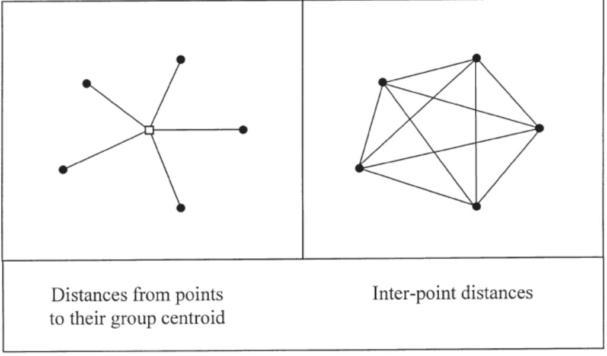

PERMANOVA, similar to MANOVA, partitions the total variation into two components: variation **among groups** and **within groups**. The test statistic used in this method, called **pseudo-F**, is calculated in the same way as the conventional ANOVA F-statistic. It represents the ratio of between-group variation to within-group variation, and higher values indicate stronger group differences.

The significance of this statistic is evaluated using a permutation procedure: the group labels of the observations are randomly reassigned many times, and the pseudo-F value is recalculated for each permutation to create a reference distribution.

# Basic Procedure

The basic procedure for PERMANOVA is as follows.

1. Convert data matrix to a distance matrix, using an appropriate distance measure.
2. Square the distance matrix.
3. Calculate three partitions of the variation: SST, SSW, and SSB.
- Total variation (total sum of squares; *SST*) – the sum of squared distances divided by the number of points.
- Variation within groups (sum of squares within groups; *SSW*) – calculated identical to *SST* but separately for each group. Add the value from each group together to yield the overall *SSW*.
- Variation between groups (sum of squares between groups; *SSB*) – calculated by simple subtraction (i.e., *SSB = SST* – *SSW).*
4. Calculate the test statistic. The test statistic is termed a ‘pseudo-*F* statistic’ to distinguish it from the traditional parametric univariate *F*-statistic, but is calculated using the same formula:

$$PseudoF=\frac{SSB/(g-1)}{SSW/(n-g)}$$
where *SSB* and *SSW* are as calculated above, $g$ is the number of groups, and $n$ is the total number of sample units.

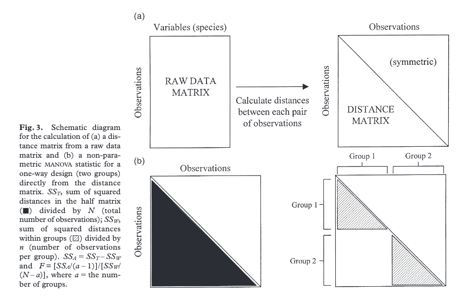

5. Assess statistical significance via a permutation test:
   - Permute group identities.
   - Recalculate pseudo-*F* statistic
   - Repeat the specified number of times. The permutations produce a distribution of pseudo-*F* values against which the actual pseudo-F statistic value is compared.
6. Calculate the p-value as the proportion of permutations that yielded a pseudo-F value equal or greater than the actual data did.

$$p=\frac{\#(PseudoF_i\geq PseudoF)}{M}, i=1,2,...,M$$

where M is the permutation number.

# Basic Example by Hand

Let’s define an imaginary dataset in R.

```r
x1<-c(1,3,5,9,10,11)
x2<-c(4,2,3,12,8,11)
group<-c("A","A","A","B","B","B")
data<-data.frame(x1,x2,group)
rownames(data)<-c("a1","a2","a3","b1","b2","b3")
```

```r
data
```

```
##    x1 x2 group
## a1  1  4     A
## a2  3  2     A
## a3  5  3     A
## b1  9 12     B
## b2 10  8     B
## b3 11 11     B
```

```r
# Calculate distance matrix
D<-dist(data[,1:2],diag = TRUE)  # eucledian distances
D
```

```
##           a1        a2        a3        b1        b2        b3
## a1  0.000000
## a2  2.828427  0.000000
## a3  4.123106  2.236068  0.000000
## b1 11.313708 11.661904  9.848858  0.000000
## b2  9.848858  9.219544  7.071068  4.123106  0.000000
## b3 12.206556 12.041595 10.000000  2.236068  3.162278  0.000000
```

```r
# Calculate squared distance matrix
D^2
```

```
##     a1  a2  a3  b1  b2  b3
## a1   0
## a2   8   0
## a3  17   5   0
## b1 128 136  97   0
## b2  97  85  50  17   0
## b3 149 145 100   5  10   0
```

$$SST=\frac{\sum{d_{ij}^2}}{n}=\frac{8+17+128+...+17+5+10}{6}=174.8333$$

```r
n<-nrow(data)
SST<-sum(D^2)/n    # (8+17+5+...+10)/6
SST
```

```
## [1] 174.8333
```

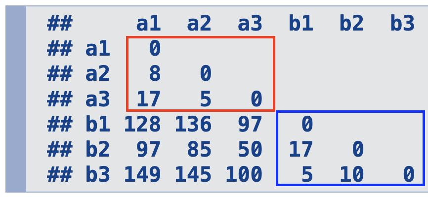

$$SSW=\sum_{k=1}^g{\frac{\sum{d_{ij}^2}}{n_k}}=\frac{8+17+5}{3}+\frac{17+5+10}{3}=\frac{30}{3}+\frac{32}{3}=20.67$$

```r
SSW=(8+17+5)/3+(17+5+10)/3
SSW
```

```
## [1] 20.66667
```

$$SSB=SST-SSW$$

```r
SSB=SST-SSW
SSB
```

```
## [1] 154.1667
```

Often, we can summarize this information in an ANOVA table:

| Source | df | SS | MS | PseudoF |
| --- | --- | --- | --- | --- |
| Between | g-1=1 | 154.1667 | 154.1667 | 29.8387 |
| Within | n-g=4 | 20.6667 | 5.1667 |  |
| Total | n-1=5 | 174.8333 |  |  |

This table contains all of the data that we usually see in an ANOVA output except the *P*-value.

Statistical significance will be determined by **permuting** the group identities, recalculating the pseudo-*F* statistic for each permutation, and comparing the observed value against the distribution of values obtained via permutation. For this purpose, we can use R programming language.

# PERMANOVA in R

We can use two popular functions to perform PERMANOVA in R:

- `adonis2()` in the package **`vegan`** (Oksanen et al. 2022).
- `PERMANOVA()` in the package **`PERMANOVA`** (Vicente-Gonzalez and Vicente-Villardon 2021).

# adonis2() function

The usage of function `adonis2()` is:

```
adonis2(
formula,
data,
permutations = 999,
method = "bray",...,)
```

- `formula` – model formula such as `Y ~ A + B * C`.
  - If `Y` is a dissimilarity matrix (i.e., output from `dist()` or `vegdist()`), the pseudo-*F* statistic is calculated directly.
  - If `Y` is a data frame or matrix containing data, `vegdist()` is applied to calculate the distance matrix first and then the pseudo-*F* statistic is calculated.
- `data` – the data frame in which the explanatory variables are located. Sample units are assumed to be in the same order in `data` as in the rows of `Y`.
- `permutations` – number of permutations to conduct to assess the significance of the pseudo-*F* statistic. Default is 999 permutations.
- `method` – method of calculating the distance matrix.

# Basic Example with the function adonis2()

```r
# when we use data directly
library(vegan)
adonis2(data[,1:2]~group,
        data=data,
        method = "euclidean")
```

```
## 'nperm' >= set of all permutations: complete enumeration.
```

```
## Set of permutations < 'minperm'. Generating entire set.
```

```
## Permutation test for adonis under reduced model
## Permutation: free
## Number of permutations: 719
##
## adonis2(formula = data[, 1:2] ~ group, data = data, method = "euclidean")
##          Df SumOfSqs      R2      F Pr(>F)
## Model     1  154.167 0.88179 29.839    0.1
## Residual  4   20.667 0.11821
## Total     5  174.833 1.00000
```

```r
# when we use distance matrix and factor
D<-dist(data[,1:2])
grp<-as.factor(data$group)
adonis2(D~grp,data=data,method = "euclidean")
```

```
## 'nperm' >= set of all permutations: complete enumeration.
```

```
## Set of permutations < 'minperm'. Generating entire set.
```

```
## Permutation test for adonis under reduced model
## Permutation: free
## Number of permutations: 719
##
## adonis2(formula = D ~ grp, data = data, method = "euclidean")
##          Df SumOfSqs      R2      F Pr(>F)
## Model     1  154.167 0.88179 29.839    0.1
## Residual  4   20.667 0.11821
## Total     5  174.833 1.00000
```

`adonis2()` function returns an ANOVA table with p-value calculated from permutations. But it returns partial $R^2$ values in the ANOVA table instead of means of SS. These $R^2$ values are calculated as below:

$$R2_{grp}=\frac{SSB}{SST}=\frac{154.167}{174.833}=0.88179$$

$$R2_{Residual}=\frac{SSW}{SST}=\frac{20.667}{174.833}=1-R2_{grp}=0.11821$$

# Distance Measures

Especially for nonparametric or permutational tests, we use distance measures instead of mean or centroids. for this reason, we will discuss about common distance measures in this section. In this section, we introduce distance measures of:

- Euclidean Distance
- Manhattan Distance
- Minkowski Distance
- Mahalanobis Distance
- Bray-Curtis Distance

# Euclidean Distance

The Euclidean distance between two points $\mathbf{x} = (x_1, x_2, \ldots, x_n)$ and $\mathbf{y} = (y_1, y_2, \ldots, y_n)$ in $n$-dimensional space is defined as:

$$d_E(x,y) = \sqrt{\sum_{i=1}^n (x_i - y_i)^2}$$

# **Manhattan Distance**

The Manhattan distance (or L1 distance) is given by:

$$d_M(x,y) = \sum_{i=1}^n |x_i - y_i|$$

# **Minkowski Distance**

The Minkowski distance is a generalization of both the Euclidean and Manhattan distances and is defined as:

$$d_{Min}(x,y) = \left( \sum_{i=1}^n |x_i - y_i|^p \right)^{1/p}$$

For $p=2$, it is the Euclidean distance. For $p=1$, it is the Manhattan distance.

# Mahalanobis Distance

The Mahalanobis distance takes into account the correlations of the data set and is defined as:

$$d_{Mah}(x,y) = \sqrt{(\mathbf{x} - \mathbf{y})^T \mathbf{S}^{-1}
(\mathbf{x} - \mathbf{y})}$$

where $\textbf{S}$ is the covariance matrix of the data.

# Bray-Curtis Distance

The Bray-Curtis distance is particularly useful when dealing with **count** data or **proportional** data. The Bray-Curtis distance (or dissimilarity) is a measure often used in ecology and other fields to quantify the compositional dissimilarity between two different sites or samples. It ranges from 0 to 1, where 0 indicates identical compositions and 1 indicates complete dissimilarity.

$$d_{BC}(x,y) = 1-\frac{2*C_{xy}}{S_x+S_y}$$

where:

- $C_{xy}$: The sum of the lesser values for the species found in each site.
- $S_x$: The total number of specimens counted at site x
- $S_y$: The total number of specimens counted at site y

# Distance Measures in R

We can use `vegdist()` function in the **`vegan`** package to calculate Euclidean, Manhattan, Minkowski, Mahalanobis, and Bray-Curtis distances.

# PISA 2022 Example

# Import data

```r
url<-"https://raw.githubusercontent.com/hsnbulut/PISA_Example/main/dataPISA.csv"
dataPISA<-read.csv(url,header = TRUE,sep = ";")
head(dataPISA,3)
```

```
##   CNT gender mathematics reading science
## 1 TUR   Male      372.86  397.79  413.01
## 2 TUR Female      446.69  448.86  463.50
## 3 TUR Female      429.03  481.61  464.37
```

Github Page: https://github.com/hsnbulut

# Factorization of Country and Gender

```r
dataPISA$CNT<-as.factor(dataPISA$CNT)
dataPISA$gender<-as.factor(dataPISA$gender)
head(dataPISA,3)
```

```
##   CNT gender mathematics reading science
## 1 TUR   Male      372.86  397.79  413.01
## 2 TUR Female      446.69  448.86  463.50
## 3 TUR Female      429.03  481.61  464.37
```

### Structure of data

```r
str(dataPISA)
```

```
## 'data.frame':    1500 obs. of  5 variables:
##  $ CNT        : Factor w/ 5 levels "CHE","CZE","FRA",..: 5 5 5 5 5 5 5 5 5 5 ...
##  $ gender     : Factor w/ 2 levels "Female","Male": 2 1 1 1 1 2 2 2 2 2 ...
##  $ mathematics: num  373 447 429 405 388 ...
##  $ reading    : num  398 449 482 417 373 ...
##  $ science    : num  413 464 464 349 399 ...
```

# Compare PISA Scores According to Country

$$H_0: \mu_1=\mu_2=\mu_3=\mu_4=\mu_5$$

$$H_1: \text{At least one of the } \mu_j \text{'s is different from
others. (j=1,2,...,5)}$$

Assumptions controls:

- Multivariate Normality
- Homogeneity

# Multivariate Normality

### Multivariate Normality for CZEch Students

```r
library(mvShapiroTest)
mvShapiro.Test(as.matrix(subset(dataPISA,
                                CNT == "CZE")[,3:5]))
```

```
##
##  Generalized Shapiro-Wilk test for Multivariate Normality by
##  Villasenor-Alva and Gonzalez-Estrada
##
## data:  as.matrix(subset(dataPISA, CNT == "CZE")[, 3:5])
## MVW = 0.99471, p-value = 0.4048
```

### Multivariate Normality for ITAlian Students

```r
mvShapiro.Test(as.matrix(subset(dataPISA,
                                CNT == "ITA")[,3:5]))
```

```
##
##  Generalized Shapiro-Wilk test for Multivariate Normality by
##  Villasenor-Alva and Gonzalez-Estrada
##
## data:  as.matrix(subset(dataPISA, CNT == "ITA")[, 3:5])
## MVW = 0.99493, p-value = 0.4706
```

# Multivariate Normality for French (FRA) Students

```r
mvShapiro.Test(as.matrix(subset(dataPISA,
                                CNT == "FRA")[,3:5]))
```

```
##
##  Generalized Shapiro-Wilk test for Multivariate Normality by
##  Villasenor-Alva and Gonzalez-Estrada
##
## data:  as.matrix(subset(dataPISA, CNT == "FRA")[, 3:5])
## MVW = 0.99501, p-value = 0.4954
```

### Multivariate Normality for Swiss (CHE) Students

```r
mvShapiro.Test(as.matrix(subset(dataPISA,
                                CNT == "CHE")[,3:5]))
```

```
##
##  Generalized Shapiro-Wilk test for Multivariate Normality by
##  Villasenor-Alva and Gonzalez-Estrada
##
## data:  as.matrix(subset(dataPISA, CNT == "CHE")[, 3:5])
## MVW = 0.99177, p-value = 0.0235
```

# Multivariate Normality for Turkish (TUR) Students

```r
mvShapiro.Test(as.matrix(subset(dataPISA,
                                CNT == "TUR")[,3:5]))
```

```
##
##  Generalized Shapiro-Wilk test for Multivariate Normality by
##  Villasenor-Alva and Gonzalez-Estrada
##
## data:  as.matrix(subset(dataPISA, CNT == "TUR")[, 3:5])
## MVW = 0.98794, p-value = 0.0002384
```

# Mardia’s Tests for MVN

```r
MVN::mvn(dataPISA[,-2],subset = "CNT",
         mvn_test = "mardia")$multivariate_normality
```

```
##    Group            Test Statistic p.value          MVN
## 1    CHE Mardia Skewness    17.372   0.067     ✓ Normal
## 2    CHE Mardia Kurtosis    -1.277   0.202     ✓ Normal
## 3    CZE Mardia Skewness    10.578   0.391     ✓ Normal
## 4    CZE Mardia Kurtosis    -0.066   0.948     ✓ Normal
## 5    FRA Mardia Skewness     7.617   0.666     ✓ Normal
## 6    FRA Mardia Kurtosis    -2.379   0.017 ✗ Not normal
## 7    ITA Mardia Skewness    15.161   0.126     ✓ Normal
## 8    ITA Mardia Kurtosis    -0.587   0.557     ✓ Normal
## 9    TUR Mardia Skewness    26.116   0.004 ✗ Not normal
## 10   TUR Mardia Kurtosis     0.193   0.847     ✓ Normal
```

# PERMANOVA

```r
str(dataPISA)
```

```
## 'data.frame':    1500 obs. of  5 variables:
##  $ CNT        : Factor w/ 5 levels "CHE","CZE","FRA",..: 5 5 5 5 5 5 5 5 5 5 ...
##  $ gender     : Factor w/ 2 levels "Female","Male": 2 1 1 1 1 2 2 2 2 2 ...
##  $ mathematics: num  373 447 429 405 388 ...
##  $ reading    : num  398 449 482 417 373 ...
##  $ science    : num  413 464 464 349 399 ...
```

```r
library(vegan)
permanova.test2<-adonis2(dataPISA[,3:5]~CNT,
                        data=dataPISA,
                        method = "euclidean")
```

```r
permanova.test2
```

```
## Permutation test for adonis under reduced model
## Permutation: free
## Number of permutations: 999
##
## adonis2(formula = dataPISA[, 3:5] ~ CNT, data = dataPISA, method = "euclidean")
##            Df SumOfSqs      R2      F Pr(>F)
## Model       4  1354406 0.03518 13.628  0.001 ***
## Residual 1495 37143855 0.96482
## Total    1499 38498261 1.00000
## ---
## Signif. codes:  0 '***' 0.001 '**' 0.01 '*' 0.05 '.' 0.1 ' ' 1
```

# References

*Applied Multivariate Statistical Analysis*. 2007. Springer Berlin Heidelberg. https://doi.org/10.1007/978-3-540-72244-1.

Bakker, Jonathan D. 2024. *Applied Multivariate Statistics in r*. University of Washington.

Bulut, Hasan. 2019a. “An r Package for Multivariate Hypothesis Tests: MVTests” 14. https://doi.org/10.12739/NWSA.2019.14.4.2A0175.

———. 2019b. “AN r PACKAGE FOR MULTIVARIATE HYPOTHESIS TESTS: MVTESTS.” *NWSA Academic Journals* 14 (4): 132–38. https://doi.org/10.12739/nwsa.2019.14.4.2a0175.

Korkmaz, Selcuk, Dincer Goksuluk, and Gokmen Zararsiz. 2014. “MVN: An R Package for Assessing Multivariate Normality.” *The R Journal* 6 (2): 151. https://doi.org/10.32614/rj-2014-031.

MARDIA, K. V. 1970. “Measures of Multivariate Skewness and Kurtosis with Applications.” *Biometrika* 57 (3): 519–30. https://doi.org/10.1093/biomet/57.3.519.

Oksanen, Jari, Gavin L. Simpson, F. Guillaume Blanchet, Roeland Kindt, Pierre Legendre, Peter R. Minchin, R. B. O’Hara, et al. 2022. “Vegan: Community Ecology Package.” https://CRAN.R-project.org/package=vegan.

Rencher, Alvin C. 2002. “Methods of Multivariate Analysis.” *Wiley Series in Probability and Statistics*, February. https://doi.org/10.1002/0471271357.

Team, R Core. 2023. “R: A Language and Environment for Statistical Computing.” https://www.R-project.org/.

Vicente-Gonzalez, Laura, and Jose Luis Vicente-Villardon. 2021. “PERMANOVA: Multivariate Analysis of Variance Based on Distances and Permutations.” https://CRAN.R-project.org/package=PERMANOVA.

Villasenor Alva, José A., and Elizabeth González Estrada. 2009. “A Generalization of ShapiroWilk’s Test for Multivariate Normality.” *Communications in Statistics - Theory and Methods* 38 (11): 1870–83. https://doi.org/10.1080/03610920802474465.